# **Homework 2**

- **Michael Kogan , ID: 318974672**
- **[Kaggle Profile](https://www.kaggle.com/michaelkogan4)**

# **About the Task**

- The goal of this task is to predict house prices on various features using regression techniques.
- I am going to look at which of this models work the best for this task: SGDRegressor, Ridge, Lasso, ElasticNet and LinearRegression.
- **Spoiler** The ElasticNet Model Won ;)

## Dataset Description

#### File descriptions

```
train.csv - the training set
test.csv - the test set
data_description.txt - full description of each column, originally prepared by Dean De Cock but lightly edited to match the column names used here
submission.csv - a benchmark submission from a linear regression on year and month of sale, lot square footage, and number of bedrooms
```

#### Data fields

Here's a brief version of what you'll find in the data description file.

```
SalePrice - the property's sale price in dollars. This is the target variable that you're trying to predict.
MSSubClass: The building class
MSZoning: The general zoning classification
LotFrontage: Linear feet of street connected to property
LotArea: Lot size in square feet
Street: Type of road access
Alley: Type of alley access
LotShape: General shape of property
LandContour: Flatness of the property
Utilities: Type of utilities available
LotConfig: Lot configuration
LandSlope: Slope of property
Neighborhood: Physical locations within Ames city limits
Condition1: Proximity to main road or railroad
Condition2: Proximity to main road or railroad (if a second is present)
BldgType: Type of dwelling
HouseStyle: Style of dwelling
OverallQual: Overall material and finish quality
OverallCond: Overall condition rating
YearBuilt: Original construction date
YearRemodAdd: Remodel date
RoofStyle: Type of roof
RoofMatl: Roof material
Exterior1st: Exterior covering on house
Exterior2nd: Exterior covering on house (if more than one material)
MasVnrType: Masonry veneer type
MasVnrArea: Masonry veneer area in square feet
ExterQual: Exterior material quality
ExterCond: Present condition of the material on the exterior
Foundation: Type of foundation
BsmtQual: Height of the basement
BsmtCond: General condition of the basement
BsmtExposure: Walkout or garden level basement walls
BsmtFinType1: Quality of basement finished area
BsmtFinSF1: Type 1 finished square feet
BsmtFinType2: Quality of second finished area (if present)
BsmtFinSF2: Type 2 finished square feet
BsmtUnfSF: Unfinished square feet of basement area
TotalBsmtSF: Total square feet of basement area
Heating: Type of heating
HeatingQC: Heating quality and condition
CentralAir: Central air conditioning
Electrical: Electrical system
1stFlrSF: First Floor square feet
2ndFlrSF: Second floor square feet
LowQualFinSF: Low quality finished square feet (all floors)
GrLivArea: Above grade (ground) living area square feet
BsmtFullBath: Basement full bathrooms
BsmtHalfBath: Basement half bathrooms
FullBath: Full bathrooms above grade
HalfBath: Half baths above grade
Bedroom: Number of bedrooms above basement level
Kitchen: Number of kitchens
KitchenQual: Kitchen quality
TotRmsAbvGrd: Total rooms above grade (does not include bathrooms)
Functional: Home functionality rating
Fireplaces: Number of fireplaces
FireplaceQu: Fireplace quality
GarageType: Garage location
GarageYrBlt: Year garage was built
GarageFinish: Interior finish of the garage
GarageCars: Size of garage in car capacity
GarageArea: Size of garage in square feet
GarageQual: Garage quality
GarageCond: Garage condition
PavedDrive: Paved driveway
WoodDeckSF: Wood deck area in square feet
OpenPorchSF: Open porch area in square feet
EnclosedPorch: Enclosed porch area in square feet
3SsnPorch: Three season porch area in square feet
ScreenPorch: Screen porch area in square feet
PoolArea: Pool area in square feet
PoolQC: Pool quality
Fence: Fence quality
MiscFeature: Miscellaneous feature not covered in other categories
MiscVal: $Value of miscellaneous feature
MoSold: Month Sold
YrSold: Year Sold
SaleType: Type of sale
SaleCondition: Condition of sale
```

## Importing NumPy, Pandas and Matplotlib

in the next few lines of code we are going to look at the data from the train and the test files. We will focus on the training data for looking which data should be kept and which should be dropped. We will explore the data a bit before diving into the graphs.

```python
import numpy as np
import pandas as pd
import matplotlib.pyplot as plt
```

```python
train_location = "house prices/train.csv"
test_location = "house prices/test.csv"
submission_location = "house prices/submission.csv"
```

```python
train_data = pd.read_csv(train_location)
test_data = pd.read_csv(test_location)
```

```python
train_data.head()
```

|  | Id | MSSubClass | MSZoning | LotFrontage | LotArea | Street | Alley | LotShape | LandContour | Utilities | ... | PoolArea | PoolQC | Fence | MiscFeature | MiscVal | MoSold | YrSold | SaleType | SaleCondition | SalePrice |
| --- | --- | --- | --- | --- | --- | --- | --- | --- | --- | --- | --- | --- | --- | --- | --- | --- | --- | --- | --- | --- | --- |
| 0 | 1 | 60 | RL | 65.0 | 8450 | Pave | NaN | Reg | Lvl | AllPub | ... | 0 | NaN | NaN | NaN | 0 | 2 | 2008 | WD | Normal | 208500 |
| 1 | 2 | 20 | RL | 80.0 | 9600 | Pave | NaN | Reg | Lvl | AllPub | ... | 0 | NaN | NaN | NaN | 0 | 5 | 2007 | WD | Normal | 181500 |
| 2 | 3 | 60 | RL | 68.0 | 11250 | Pave | NaN | IR1 | Lvl | AllPub | ... | 0 | NaN | NaN | NaN | 0 | 9 | 2008 | WD | Normal | 223500 |
| 3 | 4 | 70 | RL | 60.0 | 9550 | Pave | NaN | IR1 | Lvl | AllPub | ... | 0 | NaN | NaN | NaN | 0 | 2 | 2006 | WD | Abnorml | 140000 |
| 4 | 5 | 60 | RL | 84.0 | 14260 | Pave | NaN | IR1 | Lvl | AllPub | ... | 0 | NaN | NaN | NaN | 0 | 12 | 2008 | WD | Normal | 250000 |

5 rows × 81 columns

```python
test_data.head()
```

|  | Id | MSSubClass | MSZoning | LotFrontage | LotArea | Street | Alley | LotShape | LandContour | Utilities | ... | ScreenPorch | PoolArea | PoolQC | Fence | MiscFeature | MiscVal | MoSold | YrSold | SaleType | SaleCondition |
| --- | --- | --- | --- | --- | --- | --- | --- | --- | --- | --- | --- | --- | --- | --- | --- | --- | --- | --- | --- | --- | --- |
| 0 | 1461 | 20 | RH | 80.0 | 11622 | Pave | NaN | Reg | Lvl | AllPub | ... | 120 | 0 | NaN | MnPrv | NaN | 0 | 6 | 2010 | WD | Normal |
| 1 | 1462 | 20 | RL | 81.0 | 14267 | Pave | NaN | IR1 | Lvl | AllPub | ... | 0 | 0 | NaN | NaN | Gar2 | 12500 | 6 | 2010 | WD | Normal |
| 2 | 1463 | 60 | RL | 74.0 | 13830 | Pave | NaN | IR1 | Lvl | AllPub | ... | 0 | 0 | NaN | MnPrv | NaN | 0 | 3 | 2010 | WD | Normal |
| 3 | 1464 | 60 | RL | 78.0 | 9978 | Pave | NaN | IR1 | Lvl | AllPub | ... | 0 | 0 | NaN | NaN | NaN | 0 | 6 | 2010 | WD | Normal |
| 4 | 1465 | 120 | RL | 43.0 | 5005 | Pave | NaN | IR1 | HLS | AllPub | ... | 144 | 0 | NaN | NaN | NaN | 0 | 1 | 2010 | WD | Normal |

5 rows × 80 columns

```python
train_data.describe()
```

|  | Id | MSSubClass | LotFrontage | LotArea | OverallQual | OverallCond | YearBuilt | YearRemodAdd | MasVnrArea | BsmtFinSF1 | ... | WoodDeckSF | OpenPorchSF | EnclosedPorch | 3SsnPorch | ScreenPorch | PoolArea | MiscVal | MoSold | YrSold | SalePrice |
| --- | --- | --- | --- | --- | --- | --- | --- | --- | --- | --- | --- | --- | --- | --- | --- | --- | --- | --- | --- | --- | --- |
| count | 1460.000000 | 1460.000000 | 1201.000000 | 1460.000000 | 1460.000000 | 1460.000000 | 1460.000000 | 1460.000000 | 1452.000000 | 1460.000000 | ... | 1460.000000 | 1460.000000 | 1460.000000 | 1460.000000 | 1460.000000 | 1460.000000 | 1460.000000 | 1460.000000 | 1460.000000 | 1460.000000 |
| mean | 730.500000 | 56.897260 | 70.049958 | 10516.828082 | 6.099315 | 5.575342 | 1971.267808 | 1984.865753 | 103.685262 | 443.639726 | ... | 94.244521 | 46.660274 | 21.954110 | 3.409589 | 15.060959 | 2.758904 | 43.489041 | 6.321918 | 2007.815753 | 180921.195890 |
| std | 421.610009 | 42.300571 | 24.284752 | 9981.264932 | 1.382997 | 1.112799 | 30.202904 | 20.645407 | 181.066207 | 456.098091 | ... | 125.338794 | 66.256028 | 61.119149 | 29.317331 | 55.757415 | 40.177307 | 496.123024 | 2.703626 | 1.328095 | 79442.502883 |
| min | 1.000000 | 20.000000 | 21.000000 | 1300.000000 | 1.000000 | 1.000000 | 1872.000000 | 1950.000000 | 0.000000 | 0.000000 | ... | 0.000000 | 0.000000 | 0.000000 | 0.000000 | 0.000000 | 0.000000 | 0.000000 | 1.000000 | 2006.000000 | 34900.000000 |
| 25% | 365.750000 | 20.000000 | 59.000000 | 7553.500000 | 5.000000 | 5.000000 | 1954.000000 | 1967.000000 | 0.000000 | 0.000000 | ... | 0.000000 | 0.000000 | 0.000000 | 0.000000 | 0.000000 | 0.000000 | 0.000000 | 5.000000 | 2007.000000 | 129975.000000 |
| 50% | 730.500000 | 50.000000 | 69.000000 | 9478.500000 | 6.000000 | 5.000000 | 1973.000000 | 1994.000000 | 0.000000 | 383.500000 | ... | 0.000000 | 25.000000 | 0.000000 | 0.000000 | 0.000000 | 0.000000 | 0.000000 | 6.000000 | 2008.000000 | 163000.000000 |
| 75% | 1095.250000 | 70.000000 | 80.000000 | 11601.500000 | 7.000000 | 6.000000 | 2000.000000 | 2004.000000 | 166.000000 | 712.250000 | ... | 168.000000 | 68.000000 | 0.000000 | 0.000000 | 0.000000 | 0.000000 | 0.000000 | 8.000000 | 2009.000000 | 214000.000000 |
| max | 1460.000000 | 190.000000 | 313.000000 | 215245.000000 | 10.000000 | 9.000000 | 2010.000000 | 2010.000000 | 1600.000000 | 5644.000000 | ... | 857.000000 | 547.000000 | 552.000000 | 508.000000 | 480.000000 | 738.000000 | 15500.000000 | 12.000000 | 2010.000000 | 755000.000000 |

8 rows × 38 columns

```python
train_data.info()
```

```
<class 'pandas.core.frame.DataFrame'>
RangeIndex: 1460 entries, 0 to 1459
Data columns (total 81 columns):
 #   Column         Non-Null Count  Dtype
---  ------         --------------  -----
 0   Id             1460 non-null   int64
 1   MSSubClass     1460 non-null   int64
 2   MSZoning       1460 non-null   object
 3   LotFrontage    1201 non-null   float64
 4   LotArea        1460 non-null   int64
 5   Street         1460 non-null   object
 6   Alley          91 non-null     object
 7   LotShape       1460 non-null   object
 8   LandContour    1460 non-null   object
 9   Utilities      1460 non-null   object
```

[output cut: 73 more lines]

## Missing Values

We can see that there is a lot of missing values. In the graph below we can see the percentage of missing values for each feature in the training data is depicted in this bar plot.

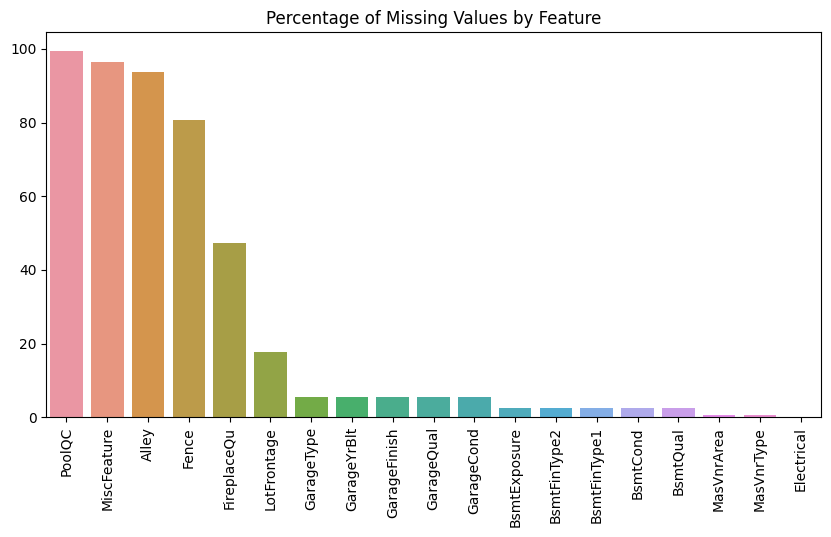

```python
import seaborn as sns

missing_values = (train_data.isnull().sum() / len(train_data)) * 100
missing_values = missing_values[missing_values > 0].sort_values(ascending=False)

plt.figure(figsize=(10,5))
sns.barplot(x=missing_values.index, y=missing_values)
plt.xticks(rotation=90)
plt.title('Percentage of Missing Values by Feature')
plt.show()
```

### Function for showing a Heatmap

```python
def showHeatmap(df, x, y, title, isAnnot):
    plt.figure(figsize=(x,y))
    sns.heatmap(df, cmap='coolwarm', annot=isAnnot)
    plt.title(title)
    plt.show()
```

### Sale Price for Houses Distribution

The distribution of the target variable, SalePrice is shown in the histogram. It helps us understand the datasets' overall distribution of housing prices.

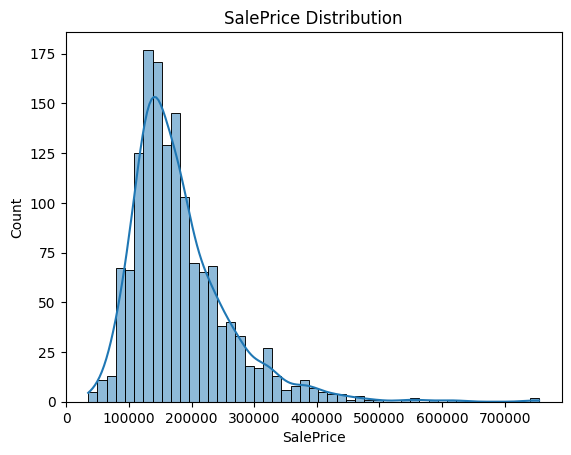

```python
sns.histplot(train_data['SalePrice'], kde=True)
plt.title('SalePrice Distribution')
plt.show()
```

### Heatmap for Correlation

The correlation between the training data's numerical features is shown in this heatmap. We can use it to determine the significance and direction of relationships between variables. Darker shades indicate positive or negative correlations. This helps us see which features are highly correlated with the target variable - SalePrice.

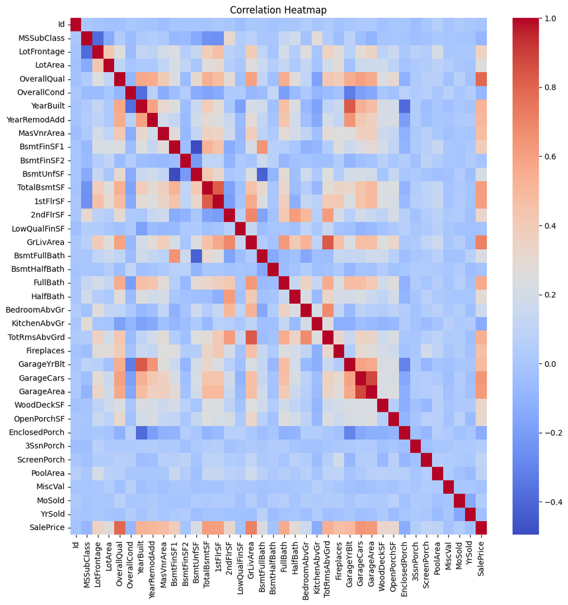

```python
corr_train_data = train_data.corr(numeric_only=True)
title = 'Correlation Heatmap'
showHeatmap(corr_train_data, 12, 12, title, False)
```

### Top 10 highly correlated features(Not encluding SalePrice as a Top 10 so starting from OverallQual

This heatmap provides a closer look at the correlations between these specific features. We can use this data to identify important predictors that may have a significant impact on the housing prices.

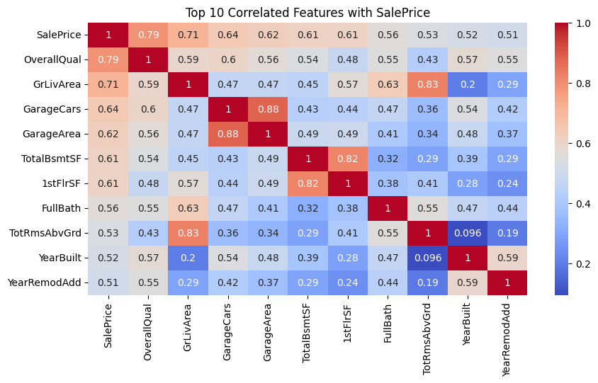

```python
corr_train_top_location = corr_train_data.nlargest(11, 'SalePrice')['SalePrice'].index
corr_train_top = train_data[corr_train_top_location].corr()
title = 'Top 10 Correlated Features with SalePrice'
showHeatmap(corr_train_top, 10, 5, title, True)
```

### Different scatters we are gonna pick a few

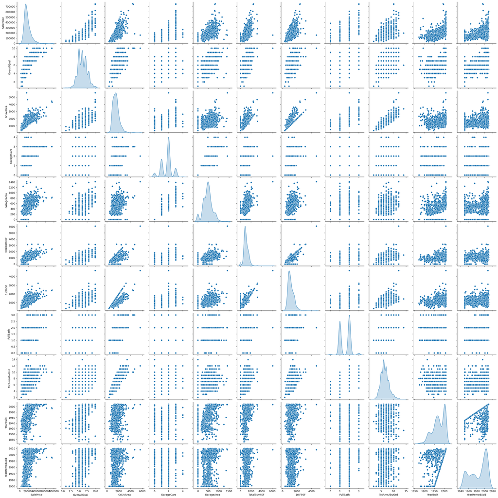

```python
sns.pairplot(train_data[corr_train_top_location], diag_kind='kde')
```

### Function for showing a Scatter plot

```python
def showScatterPlot(df, x_axis, y_axis, sizeX, sizeY, title):
    plt.figure(figsize=(sizeX, sizeY))
    sns.scatterplot(x=x_axis, y=y_axis, data=df, alpha=0.5)
    plt.title(title)
    plt.show()
```

### SalePrice v YearBuilt Scatter

This scatter illustrates the relationship between the sale price of a house and the year it was built. It aids in the visualization of any potential trends or patterns in housing prices based on the year of construction. Understanding thid relationship can help to explain how property age affect prices.

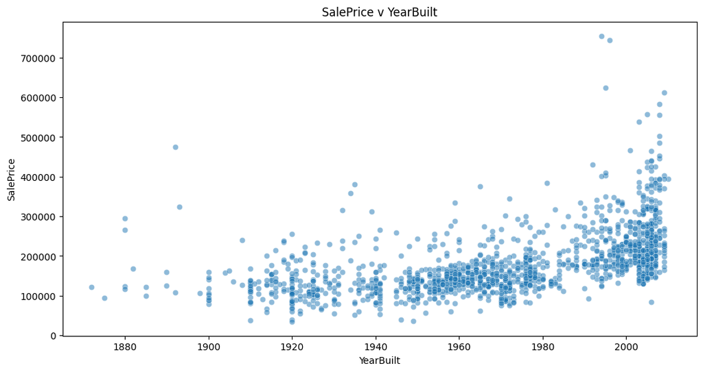

```python
x_axis = 'YearBuilt'
y_axis = 'SalePrice'
title = 'SalePrice v YearBuilt'
showScatterPlot(train_data, x_axis, y_axis, 12, 6, title)
```

### SalePrice v GrLivArea

This scatter plot represents the relationship between the above-ground living area and the sale price of the houses. It allows us th observe how the size of the living area affects the house prices.

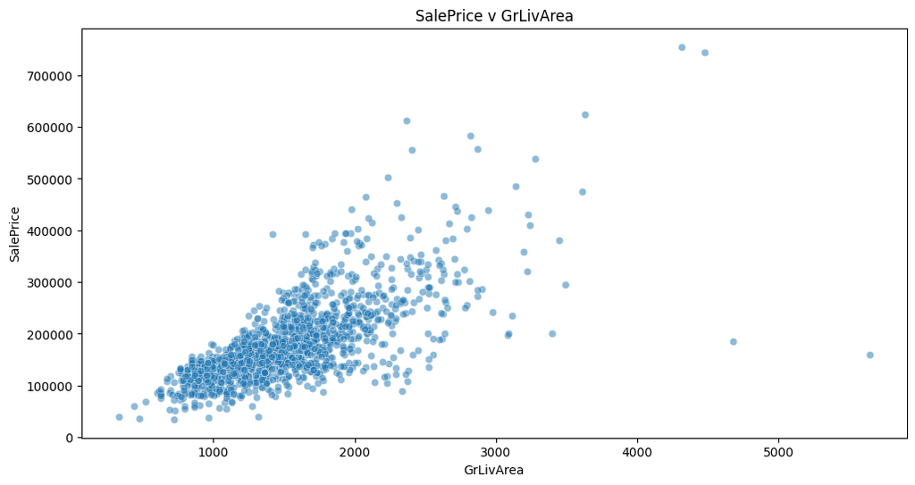

```python
x_axis = 'GrLivArea'
y_axis = 'SalePrice'
title = 'SalePrice v GrLivArea'
showScatterPlot(train_data, x_axis, y_axis, 12, 6, title)
```

### SalePrice v TotalBsmtSF

This scatter plot illustrates the relationship between the total basement area and the sale proce of houses. It enables us to examine the relationship between basement size and corresponding house prices.

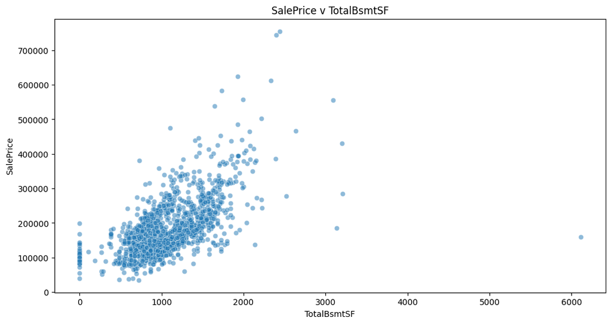

```python
x_axis = 'TotalBsmtSF'
y_axis = 'SalePrice'
title = 'SalePrice v TotalBsmtSF'
showScatterPlot(train_data, x_axis, y_axis, 12, 6, title)
```

### SalePrice v GarageArea

This scatter plot is the relationship between the Garage area and sale price of houses. It again gives us the opportunity to explore yet another feature that can influence the house prices.

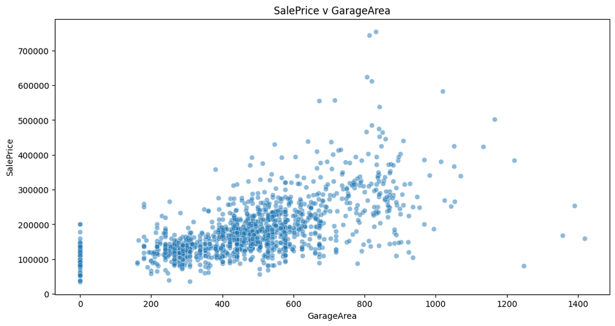

```python
x_axis = 'GarageArea'
y_axis = 'SalePrice'
title = 'SalePrice v GarageArea'
showScatterPlot(train_data, x_axis, y_axis, 12, 6, title)
```

### SalePrice v 1stFlrSF

This scatter plot displays the relationship between the first-floor area and the house price. It again enables us to analyze the connection between the size of the floor and the house prices.

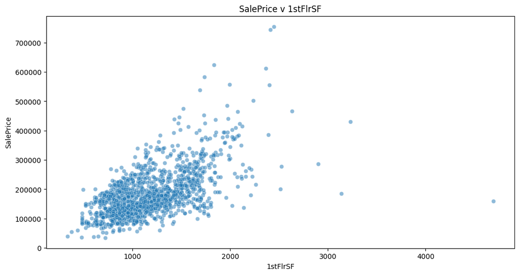

```python
x_axis = '1stFlrSF'
y_axis = 'SalePrice'
title = 'SalePrice v 1stFlrSF'
showScatterPlot(train_data, x_axis, y_axis, 12, 6, title)
```

### The Visuals We Have Seen

They help us understand that a lot of features determine the house of the prices and that they are mostly all very important for the data that will be processed for the different models to learn from to try to predict the right prices for this Kaggle task.

## Data Preprocessing and Feature Engineering

Here we will preprocess the data We will use Preprocessing pipelines, they will be used to do the preprocess fpr the numerical and categorical features.

We will use the StandardScaler and SimpleImputer for the numerical and SimpleImputer and OneHotEncoder for the categorical.

We have a lot of data to play here with, so working one by one on it is harder and it would be better to use a build in library. We then will use the ColumnTransformer to define the different types of columns in our dataset. By creating those pipelines and using the ColumnTransformer we make for us a more easy experience in building the model for this task.

```python
drop = ['PoolQC', 'MiscFeature', 'Alley', 'Fence', 'FireplaceQu']
train_data = train_data.drop(drop, axis=1)
test_data = test_data.drop(drop, axis=1)
```

```python
X = train_data.drop('SalePrice', axis=1)
y = train_data['SalePrice']
```

```python
from sklearn.model_selection import train_test_split

X_train, X_val, y_train, y_val = train_test_split(X, y, test_size=0.2, random_state=42)
```

```python
from sklearn.pipeline import Pipeline
from sklearn.impute import SimpleImputer
from sklearn.preprocessing import StandardScaler, OneHotEncoder

numerical_pipeline = Pipeline([
    ('imputer', SimpleImputer(strategy='median')),
    ('scaler', StandardScaler())
])

categorical_pipeline = Pipeline([
    ('imputer', SimpleImputer(strategy='most_frequent')),
    ('onehot', OneHotEncoder(handle_unknown='ignore'))
])
```

```python
from sklearn.compose import ColumnTransformer

preprocessor = ColumnTransformer([
    ('num', numerical_pipeline, X.select_dtypes(include=[np.number]).columns),
    ('cat', categorical_pipeline, X.select_dtypes(include=['object']).columns)
])
```

## Model Training and Evaluation

Here we will train and evaluate the regression models, we will evaluate the best working model and use it, we can change if needed the model in the if statement if we want to use a specific model.

```python
from sklearn.linear_model import SGDRegressor, Ridge, Lasso, ElasticNet, LinearRegression

models = [
    ('SGD', SGDRegressor(random_state=42)),
    ('Ridge', Ridge(random_state=42)),
    ('Lasso', Lasso(random_state=42)),
    ('ElasticNet', ElasticNet(random_state=42)),
    ('Linear', LinearRegression())
]
```

```python
from sklearn.metrics import mean_squared_error

for name, model in models:
    pipeline = Pipeline([
        ('preprocessor', preprocessor),
        ('model', model)
    ])
    pipeline.fit(X_train, y_train)
    y_val_pred = pipeline.predict(X_val)
    mse = mean_squared_error(y_val, y_val_pred)
    rmse = np.sqrt(mse)
    if name == 'ElasticNet':
        model_choice = model
        pipeline_choice = pipeline
        name_choice = name
    print(f"{name} - RMSE: {rmse:.2f}, MSE: {mse:.2f}")
```

```
SGD - RMSE: 33999.54, MSE: 1155968813.94
Ridge - RMSE: 29108.84, MSE: 847324625.25
Lasso - RMSE: 28166.25, MSE: 793337400.27
ElasticNet - RMSE: 36305.41, MSE: 1318082754.63
Linear - RMSE: 29558.48, MSE: 873703686.79
```

### There Was a Catch Here

Although the Lasso Model has the lowest RMSE it was slightly worser than the ElasticNet model in the final submission to Kaggle.

- SGD Best = 0.17894
- Ridge Best = 0.18183
- ElasticNet = 0.15163
- Linear = 0.18895
- Lasso = 0.1851

```python
y_val_pred = pipeline_choice.predict(X_val)
mse = mean_squared_error(y_val, y_val_pred)
rmse = np.sqrt(mse)
print(f"{name_choice} - RMSE: {rmse:.2f}, MSE: {mse:.2f}")
```

```
ElasticNet - RMSE: 36305.41, MSE: 1318082754.63
```

## Checking the score

```python
pipeline_choice.fit(X,y)
```

```
Pipeline(steps=[('preprocessor',
                 ColumnTransformer(transformers=[('num',
                                                  Pipeline(steps=[('imputer',
                                                                   SimpleImputer(strategy='median')),
                                                                  ('scaler',
                                                                   StandardScaler())]),
                                                  Index(['Id', 'MSSubClass', 'LotFrontage', 'LotArea', 'OverallQual',
       'OverallCond', 'YearBuilt', 'YearRemodAdd', 'MasVnrArea', 'BsmtFinSF1',
       'BsmtFinSF2', 'BsmtUnfSF', 'TotalBsmtSF', '1stFlrSF', '2ndFlrS...
       'Exterior2nd', 'MasVnrType', 'ExterQual', 'ExterCond', 'Foundation',
       'BsmtQual', 'BsmtCond', 'BsmtExposure', 'BsmtFinType1', 'BsmtFinType2',
       'Heating', 'HeatingQC', 'CentralAir', 'Electrical', 'KitchenQual',
       'Functional', 'GarageType', 'GarageFinish', 'GarageQual', 'GarageCond',
       'PavedDrive', 'SaleType', 'SaleCondition'],
      dtype='object'))])),
                ('model', ElasticNet(random_state=42))])
```

## Using the model on the test_data and Submitting

```python
X_test = test_data
y_test_pred = pipeline_choice.predict(X_test)
```

```python
submission = pd.DataFrame({'Id': test_data['Id'], 'SalePrice': y_test_pred})
```

```python
submission.to_csv(submission_location, index=False)
```

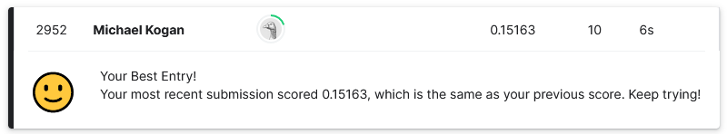

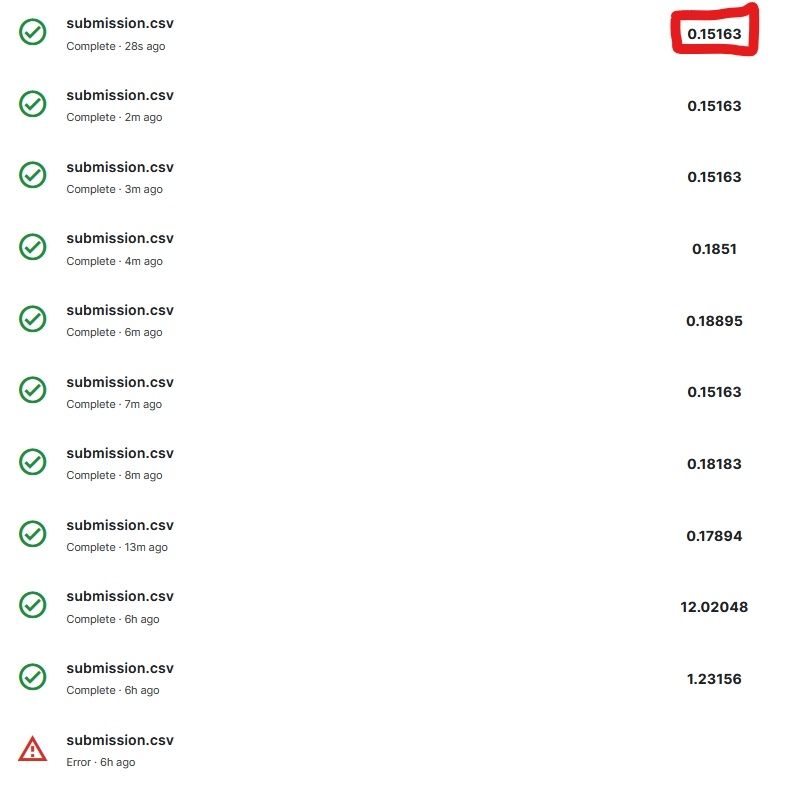

## Summery

Overall it was fun.. long.. but fun. I learned now how to better use data and different libraries that really help and ease the process so.. for the better I guess. And also learned more about how to work with more models

## References

- A lot of YouTube videos explaining how to work with pipelines
- Sci-kit-learn website:
- https://scikit-learn.org/stable/auto_examples/compose/plot_digits_pipe.html
- https://scikit-learn.org/stable/modules/generated/sklearn.linear_model.SGDRegressor.html#sklearn.linear_model.SGDRegressor
- https://scikit-learn.org/stable/modules/generated/sklearn.linear_model.Ridge.html#sklearn.linear_model.Ridge
- https://scikit-learn.org/stable/modules/linear_model.html#lasso
- https://scikit-learn.org/stable/modules/generated/sklearn.linear_model.ElasticNet.html#sklearn.linear_model.ElasticNet
- Practice notebooks P04_FourthPracticeML_2022 to P07_SeventhPracticeML_2022 inclusive.